# R Notebook

#Setting Up CRAN Repository

```r
#This sets the CRAN repository to ensure package installation from a reliable source.
# Set the CRAN Repository
options(repos = c(CRAN = "https://cloud.r-project.org/"))
```

#Installing Required Packages

```r
packages <- c("tidyverse", "openxlsx", "knitr", "dplyr", "MASS", "pscl", "pROC", "car", "tidyr", "ggplot2", "corrplot")
install_if_missing <- function(p) {
  if (!p %in% installed.packages()[, "Package"]) install.packages(p)
}
sapply(packages, install_if_missing)
```

#Setting the Working Directory and Loading Data

```r
setwd("G:/UMBC_Academics/HIT_750_Data Analytics/Project/Week 1")  # Path of Woring directory
list.files()
```

```
[1] "diabetes_dataset.csv"
[2] "Diabetics_analysis.docx"
[3] "Diabetics_analysis.nb.html"
[4] "Diabetics_analysis.Rmd"
[5] "Diabetics_analysis.tex"
[6] "Exploring the Impact of Lifestyle and Health Factors on Diabetes Risk.pdf"
[7] "random_forest_model.rds"
[8] "Statistical Analysis Using BRFSS Data (1) (1).pptx"
[9] "VariableTable.xlsx"
```

```r
data <- read.csv("diabetes_dataset.csv")  # Dataset filename
```

#Loading the Variable Table

```r
# Load the openxlsx package to work with Excel files
library(openxlsx)
# Load the knitr package for rendering tables
library(knitr)

# Set the path to the Excel file on your local machine
# Update this path to where the file is located on your system
file_path <- "G:/UMBC_Academics/HIT_750_Data Analytics/Project/Week 1/VariableTable.xlsx"

# Read the Excel sheet into a variable (assuming it's in the first sheet)
variable <- read.xlsx(file_path, sheet = 1)

# View the data in the notebook using knitr's kable function
kable(variable, caption = "Variable Table from Excel")
```

Variable Table from Excel

| Variable | Description | Data.Type |
| --- | --- | --- |
| ID | Patient ID | Integer |
| Diabetes_binary | 0 = no diabetes 1 = prediabetes or diabetes | Binary |
| HighBP | 0 = no high BP 1 = high BP | Binary |
| HighChol | 0 = no high cholesterol 1 = high cholesterol | Binary |
| CholCheck | 0 = no cholesterol check in 5 years 1 = yes cholesterol check in 5 years | Binary |
| BMI | Body Mass Index | Integer |
| Smoker | Have you smoked at least 100 cigarettes in your entire life? [Note: 5 packs = 100 cigarettes] 0 = no 1 = yes | Binary |
| Stroke | (Ever told) you had a stroke. 0 = no 1 = yes | Binary |
| HeartDiseaseorAttack | coronary heart disease (CHD) or myocardial infarction (MI) 0 = no 1 = yes | Binary |
| PhysActivity | physical activity in past 30 days - not including job 0 = no 1 = yes | Binary |
| Fruits | Consume Fruit 1 or more times per day 0 = no 1 = yes | Binary |
| Veggies | Consume Vegetables 1 or more times per day 0 = no 1 = yes | Binary |
| HvyAlcoholConsump | Heavy drinkers (adult men having more than 14 drinks per week and adult women having more than 7 drinks per week) 0 = no 1 = yes | Binary |
| AnyHealthcare | Have any kind of health care coverage, including health insurance, prepaid plans such as HMO, etc. 0 = no 1 = yes | Binary |
| NoDocbcCost | Was there a time in the past 12 months when you needed to see a doctor but could not because of cost? 0 = no 1 = yes | Binary |
| GenHlth | Would you say that in general your health is: scale 1-5 1 = excellent 2 = very good 3 = good 4 = fair 5 = poor | Integer |
| MentHlth | Now thinking about your mental health, which includes stress, depression, and problems with emotions, for how many days during the past 30 days was your mental health not good? scale 1-30 days | Integer |
| PhysHlth | Now thinking about your physical health, which includes physical illness and injury, for how many days during the past 30 days was your physical health not good? scale 1-30 days | Integer |
| DiffWalk | Do you have serious difficulty walking or climbing stairs? 0 = no 1 = yes | Binary |
| Sex | 0 = female 1 = male | Binary |
| Age | 13-level age category (_AGEG5YR see codebook) 1 = 18-24 9 = 60-64 13 = 80 or older | Integer |
| Education | Education level (EDUCA see codebook) scale 1-6 1 = Never attended school or only kindergarten 2 = Grades 1 through 8 (Elementary) 3 = Grades 9 through 11 (Some high school) 4 = Grade 12 or GED (High s… | Integer |
| Income | Income scale (INCOME2 see codebook) scale 1-8 1 = less than $10,000 5 = less than $35,000 8 = $75,000 or more | Integer |

#Calculating Summary Statistics for Numeric Variables

```r
# Load necessary packages
library(knitr)
library(dplyr)
library(tidyr)
# Set the correct path to your local dataset
data <- read.csv("G:/UMBC_Academics/HIT_750_Data Analytics/Project/Week 1/diabetes_dataset.csv")

# Function to calculate summary statistics
calc_summary_stats <- function(x) {
  c(
    Min = min(x, na.rm = TRUE),
    `1st Qu.` = quantile(x, 0.25, na.rm = TRUE),
    Median = median(x, na.rm = TRUE),
    Mean = mean(x, na.rm = TRUE),
    `3rd Qu.` = quantile(x, 0.75, na.rm = TRUE),
    Max = max(x, na.rm = TRUE)
  )
}

# Apply the function to each numeric variable in the dataset
summary_stats <- data %>%
  select_if(is.numeric) %>%
  summarise_all(list(calc_summary_stats))
# Unnest the list columns generated by summarise_all
summary_stats_unnested <- summary_stats %>%
  unnest(cols = everything(), names_repair = "minimal")

# Transpose the summary statistics for better readability
summary_stats_t <- t(summary_stats_unnested)

# Convert the transposed summary stats into a data frame
summary_df <- as.data.frame(summary_stats_t)

# Set proper column names after transposing
colnames(summary_df) <- c("Min", "1st Qu.", "Median", "Mean", "3rd Qu.", "Max")

# Add the variable names as a separate column
summary_df$Variable <- rownames(summary_df)

# Reorder the columns to place the Variable column first
summary_df <- summary_df[, c("Variable", "Min", "1st Qu.", "Median", "Mean", "3rd Qu.", "Max")]

# Print the final summary_df to debug
print(summary_df)
```

|  | Variable | Min | 1st Qu. | Median | Mean | 3rd Qu. | Max |
| --- | --- | --- | --- | --- | --- | --- | --- |
| Diabetes_binary | Diabetes_binary | 0 | 0 | 0 | 0.13933302 | 0 | 1 |
| HighBP | HighBP | 0 | 0 | 0 | 0.42900110 | 1 | 1 |
| HighChol | HighChol | 0 | 0 | 0 | 0.42412094 | 1 | 1 |
| CholCheck | CholCheck | 0 | 1 | 1 | 0.96266950 | 1 | 1 |
| BMI | BMI | 12 | 24 | 27 | 28.38236361 | 31 | 98 |
| Smoker | Smoker | 0 | 0 | 0 | 0.44316856 | 1 | 1 |
| Stroke | Stroke | 0 | 0 | 0 | 0.04057080 | 0 | 1 |
| HeartDiseaseorAttack | HeartDiseaseorAttack | 0 | 0 | 0 | 0.09418559 | 0 | 1 |
| PhysActivity | PhysActivity | 0 | 1 | 1 | 0.75654368 | 1 | 1 |
| Fruits | Fruits | 0 | 0 | 1 | 0.63425576 | 1 | 1 |

[output cut: 12 more lines]

```r
# Print the formatted summary statistics table
kable(summary_df, format = "latex", row.names = FALSE)
```

```r
NA
```

#Displaying Dataset Summary and Structure

```r
# Summary statistics for the dataset
summary(data)
```

```
 Diabetes_binary      HighBP         HighChol        CholCheck           BMI            Smoker           Stroke
 Min.   :0.0000   Min.   :0.000   Min.   :0.0000   Min.   :0.0000   Min.   :12.00   Min.   :0.0000   Min.   :0.00000
 1st Qu.:0.0000   1st Qu.:0.000   1st Qu.:0.0000   1st Qu.:1.0000   1st Qu.:24.00   1st Qu.:0.0000   1st Qu.:0.00000
 Median :0.0000   Median :0.000   Median :0.0000   Median :1.0000   Median :27.00   Median :0.0000   Median :0.00000
 Mean   :0.1393   Mean   :0.429   Mean   :0.4241   Mean   :0.9627   Mean   :28.38   Mean   :0.4432   Mean   :0.04057
 3rd Qu.:0.0000   3rd Qu.:1.000   3rd Qu.:1.0000   3rd Qu.:1.0000   3rd Qu.:31.00   3rd Qu.:1.0000   3rd Qu.:0.00000
 Max.   :1.0000   Max.   :1.000   Max.   :1.0000   Max.   :1.0000   Max.   :98.00   Max.   :1.0000   Max.   :1.00000
 HeartDiseaseorAttack  PhysActivity        Fruits          Veggies       HvyAlcoholConsump AnyHealthcare
 Min.   :0.00000      Min.   :0.0000   Min.   :0.0000   Min.   :0.0000   Min.   :0.0000    Min.   :0.0000
 1st Qu.:0.00000      1st Qu.:1.0000   1st Qu.:0.0000   1st Qu.:1.0000   1st Qu.:0.0000    1st Qu.:1.0000
 Median :0.00000      Median :1.0000   Median :1.0000   Median :1.0000   Median :0.0000    Median :1.0000
 Mean   :0.09419      Mean   :0.7565   Mean   :0.6343   Mean   :0.8114   Mean   :0.0562    Mean   :0.9511
 3rd Qu.:0.00000      3rd Qu.:1.0000   3rd Qu.:1.0000   3rd Qu.:1.0000   3rd Qu.:0.0000    3rd Qu.:1.0000
 Max.   :1.00000      Max.   :1.0000   Max.   :1.0000   Max.   :1.0000   Max.   :1.0000    Max.   :1.0000
  NoDocbcCost         GenHlth         MentHlth         PhysHlth         DiffWalk           Sex              Age
 Min.   :0.00000   Min.   :1.000   Min.   : 0.000   Min.   : 0.000   Min.   :0.0000   Min.   :0.0000   Min.   : 1.000
 1st Qu.:0.00000   1st Qu.:2.000   1st Qu.: 0.000   1st Qu.: 0.000   1st Qu.:0.0000   1st Qu.:0.0000   1st Qu.: 6.000
 Median :0.00000   Median :2.000   Median : 0.000   Median : 0.000   Median :0.0000   Median :0.0000   Median : 8.000
 Mean   :0.08418   Mean   :2.511   Mean   : 3.185   Mean   : 4.242   Mean   :0.1682   Mean   :0.4403   Mean   : 8.032
 3rd Qu.:0.00000   3rd Qu.:3.000   3rd Qu.: 2.000   3rd Qu.: 3.000   3rd Qu.:0.0000   3rd Qu.:1.0000   3rd Qu.:10.000
 Max.   :1.00000   Max.   :5.000   Max.   :30.000   Max.   :30.000   Max.   :1.0000   Max.   :1.0000   Max.   :13.000
   Education        Income
 Min.   :1.00   Min.   :1.000
 1st Qu.:4.00   1st Qu.:5.000
 Median :5.00   Median :7.000
 Mean   :5.05   Mean   :6.054
 3rd Qu.:6.00   3rd Qu.:8.000
 Max.   :6.00   Max.   :8.000
```

```r
# Check the structure of the dataset
str(data)
```

```
'data.frame':   253680 obs. of  22 variables:
 $ Diabetes_binary     : num  0 0 0 0 0 0 0 0 1 0 ...
 $ HighBP              : num  1 0 1 1 1 1 1 1 1 0 ...
 $ HighChol            : num  1 0 1 0 1 1 0 1 1 0 ...
 $ CholCheck           : num  1 0 1 1 1 1 1 1 1 1 ...
 $ BMI                 : num  40 25 28 27 24 25 30 25 30 24 ...
 $ Smoker              : num  1 1 0 0 0 1 1 1 1 0 ...
 $ Stroke              : num  0 0 0 0 0 0 0 0 0 0 ...
 $ HeartDiseaseorAttack: num  0 0 0 0 0 0 0 0 1 0 ...
 $ PhysActivity        : num  0 1 0 1 1 1 0 1 0 0 ...
 $ Fruits              : num  0 0 1 1 1 1 0 0 1 0 ...
 $ Veggies             : num  1 0 0 1 1 1 0 1 1 1 ...
 $ HvyAlcoholConsump   : num  0 0 0 0 0 0 0 0 0 0 ...
 $ AnyHealthcare       : num  1 0 1 1 1 1 1 1 1 1 ...
 $ NoDocbcCost         : num  0 1 1 0 0 0 0 0 0 0 ...
 $ GenHlth             : num  5 3 5 2 2 2 3 3 5 2 ...
 $ MentHlth            : num  18 0 30 0 3 0 0 0 30 0 ...
 $ PhysHlth            : num  15 0 30 0 0 2 14 0 30 0 ...
 $ DiffWalk            : num  1 0 1 0 0 0 0 1 1 0 ...
 $ Sex                 : num  0 0 0 0 0 1 0 0 0 1 ...
 $ Age                 : num  9 7 9 11 11 10 9 11 9 8 ...
 $ Education           : num  4 6 4 3 5 6 6 4 5 4 ...
 $ Income              : num  3 1 8 6 4 8 7 4 1 3 ...
```

#Check for missing values in the dataset

```r
# Check for missing values in the dataset
missing_values <- colSums(is.na(data))

# Filter out variables with missing values and create a neat output
missing_summary <- missing_values[missing_values > 0]

# Print the number of missing values in a neat format
if(length(missing_summary) > 0) {
  cat("Number of missing values in the dataset:\n")
  for(variable in names(missing_summary)) {
    cat(variable, ":", missing_summary[variable], "\n")
  }
} else {
  cat("There are no missing values in the dataset.\n")
}
```

```
There are no missing values in the dataset.
```

```r
install.packages("ggplot2")
```

```
Error in install.packages : Updating loaded packages
```

#Plotting the Distribution of BMI

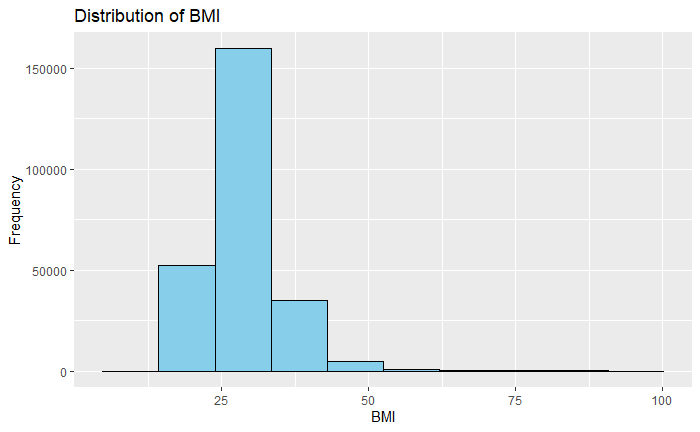

```r
library(ggplot2)
# Histogram of BMI
ggplot(data, aes(x = BMI)) +
  geom_histogram(bins = 10, fill = "skyblue", color = "black") +
  labs(title = "Distribution of BMI", x = "BMI", y = "Frequency")
```

#Counting Individuals with High Blood Pressure

```r
# Count the number of people with and without high blood pressure
highbp_count <- table(data$HighBP)

# Display the counts in a neat format
highbp_count_df <- as.data.frame(highbp_count)
colnames(highbp_count_df) <- c("HighBP_Status", "Count")

# Print the summary
print(highbp_count_df)
```

| HighBP_Status | Count |
| --- | --- |
| 0 | 144851 |
| 1 | 108829 |

```r
NA
```

#Plotting High Cholesterol Status

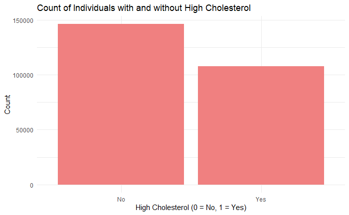

```r
# Load ggplot2 if not already loaded
library(ggplot2)

# Create a bar plot for High Cholesterol status
ggplot(data, aes(x = as.factor(HighChol))) +
  geom_bar(fill = "lightcoral") +
  labs(title = "Count of Individuals with and without High Cholesterol",
       x = "High Cholesterol (0 = No, 1 = Yes)",
       y = "Count") +
  scale_x_discrete(labels = c("0" = "No", "1" = "Yes")) +
  theme_minimal()
```

#Correlation Analysis and Plotting

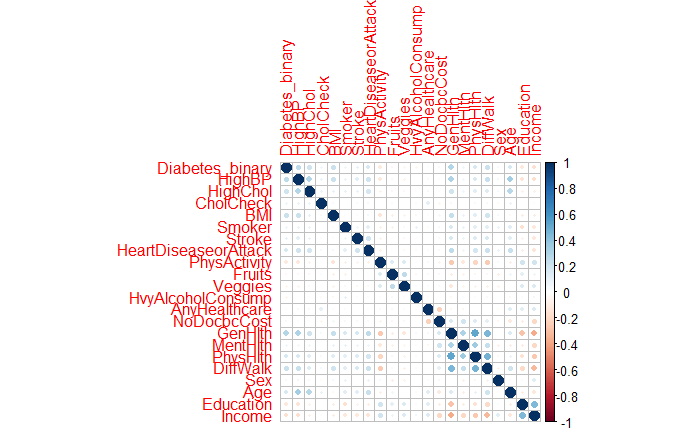

```r
install.packages("corrplot")
# Load necessary package
library(corrplot)
# Calculate the correlation matrix
cor_matrix <- cor(select(data, where(is.numeric)))

# Create a correlation plot
corrplot(cor_matrix, method = "circle")
```

#BMI by High Blood Pressure

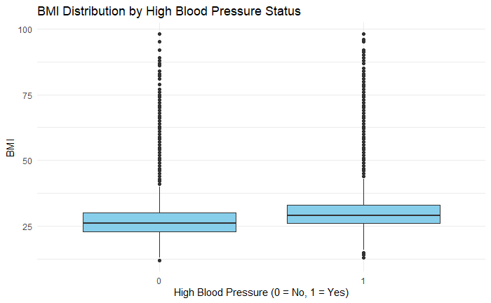

```r
# Boxplot of BMI by High Blood Pressure
ggplot(data, aes(x = as.factor(HighBP), y = BMI)) +
  geom_boxplot(fill = "skyblue") +
  labs(title = "BMI Distribution by High Blood Pressure Status", x = "High Blood Pressure (0 = No, 1 = Yes)", y = "BMI") +
  theme_minimal()
```

```r
getwd()
```

```
[1] "G:/UMBC_Academics/HIT_750_Data Analytics/Project/Week 1"
```

# Step 3: Inferential Statistics - Chi-Square Test for Categorical Variables

The Chi-Square test is used to evaluate the association between categorical variables. In this project, we are interested in understanding how certain factors, such as high blood pressure, high cholesterol, and physical activity, relate to diabetes status. Specifically, we aim to determine whether the distribution of diabetes status (diabetic vs. non-diabetic) is independent of these categorical factors.

This section evaluates the association between categorical variables (`HighBP`, `HighChol`, `PhysActivity`) and diabetes status.

```r
# Disable scientific notation
options(scipen=999)

# Chi-Square test for High Blood Pressure and Diabetes Status
chisq_highbp <- chisq.test(data$HighBP, data$Diabetes_binary)
print(chisq_highbp)  # Print the results
```

```
    Pearson's Chi-squared test with Yates' continuity correction

data:  data$HighBP and data$Diabetes_binary
X-squared = 17562, df = 1, p-value < 0.00000000000000022
```

```r
# Chi-Square test for High Cholesterol and Diabetes Status
chisq_highchol <- chisq.test(data$HighChol, data$Diabetes_binary)
print(chisq_highchol)  # Print the results
```

```
    Pearson's Chi-squared test with Yates' continuity correction

data:  data$HighChol and data$Diabetes_binary
X-squared = 10174, df = 1, p-value < 0.00000000000000022
```

```r
# Chi-Square test for Physical Activity and Diabetes Status
chisq_physactivity <- chisq.test(data$PhysActivity, data$Diabetes_binary)
print(chisq_physactivity)  # Print the results
```

```
    Pearson's Chi-squared test with Yates' continuity correction

data:  data$PhysActivity and data$Diabetes_binary
X-squared = 3539.4, df = 1, p-value < 0.00000000000000022
```

```r
# Re-enable scientific notation
options(scipen=0)
```

## Chi-Squared Value (X-squared):

This value indicates the strength of the association between the categorical variables. A higher chi-squared value suggests a greater discrepancy between the observed frequencies and the expected frequencies under the null hypothesis (which states that there is no association between the variables).

## Degrees of Freedom (df):

This value is determined by the number of categories in each variable. In this case, since both variables in each test are binary (e.g., HighBP is Yes/No), the degrees of freedom is 1 (calculated as (number of categories in variable A - 1) * (number of categories in variable B - 1)).

## p-value:

The p-value indicates the probability of observing the data (or something more extreme) if the null hypothesis were true. A very small p-value (typically < 0.05) suggests that you can reject the null hypothesis. In our output, the p-values for all three tests are extremely small (< 0.00000000000000022), indicating that there is a statistically significant association between the categorical variables and diabetes status.

## Step 4: Inferential Statistics - T-test for Continuous Variable

In this step, we will conduct a Welch Two Sample t-test to compare the means of Body Mass Index (BMI) between individuals with diabetes and those without.

# T-test for BMI

The t-test is a statistical method used to determine whether there is a significant difference between the means of two groups. We will perform the t-test using the following code:

```r
# Perform Welch Two Sample t-test
t_test_result <- t.test(data$BMI ~ data$Diabetes_binary)

# Extract components from the test result
t_statistic <- t_test_result$statistic
df <- t_test_result$parameter
p_value <- t_test_result$p.value
conf_int <- t_test_result$conf.int
mean_group1 <- t_test_result$estimate[1]
mean_group2 <- t_test_result$estimate[2]

# Formatting the output
cat("Welch Two Sample t-test\n\n")
```

```
Welch Two Sample t-test
```

```r
cat("Data: `data$BMI` by `data$Diabetes_binary`\n\n")
```

```
Data: `data$BMI` by `data$Diabetes_binary`
```

```r
cat(paste("t-statistic: ", round(t_statistic, 2), "\n", sep = ""))
```

```
t-statistic: -99.92
```

```r
cat(paste("Degrees of freedom (df): ", round(df, 3), "\n", sep = ""))
```

```
Degrees of freedom (df): 44093.403
```

```r
cat(paste("p-value: ", format.pval(p_value, digits = 20), "\n\n", sep = ""))
```

```
p-value: < 2.22044604925031308e-16
```

```r
cat("Alternative Hypothesis:\n")
```

```
Alternative Hypothesis:
```

```r
cat("The true difference in means between the group \"No Diabetes\" and the group \"Diabetes or Pre-diabetes\" is not equal to 0.\n\n")
```

```
The true difference in means between the group "No Diabetes" and the group "Diabetes or Pre-diabetes" is not equal to 0.
```

```r
cat("95% Confidence Interval:\n")
```

```
95% Confidence Interval:
```

```r
cat(paste("• Lower bound: ", round(conf_int[1], 6), "\n", sep = ""))
```

```
• Lower bound: -4.219416
```

```r
cat(paste("• Upper bound: ", round(conf_int[2], 6), "\n\n", sep = ""))
```

```
• Upper bound: -4.057065
```

```r
cat("Sample Estimates:\n")
```

```
Sample Estimates:
```

```r
cat(paste("• Mean BMI in the \"No Diabetes\" group: ", round(mean_group1, 5), "\n", sep = ""))
```

```
• Mean BMI in the "No Diabetes" group: 27.80577
```

```r
cat(paste("• Mean BMI in the \"Diabetes or Pre-diabetes\" group: ", round(mean_group2, 5), "\n", sep = ""))
```

```
• Mean BMI in the "Diabetes or Pre-diabetes" group: 31.94401
```

## t-statistic: -99.92

This value measures the size of the difference relative to the variation in the sample data. A large absolute value (far from zero) suggests that the means of the two groups are significantly different.

## 95% Confidence Interval:

Lower bound: -4.219416 Upper bound: -4.057065 This interval estimates the range in which the true difference in means lies with 95% confidence. Since both bounds are negative, it reinforces the conclusion that the mean BMI in the “Diabetes or Pre-diabetes” group is significantly higher than in the “No Diabetes” group.

## Alternative Hypothesis:

The true difference in means between the group ‘No Diabetes’ and the group ‘Diabetes or Pre-diabetes’ is not equal to 0. This indicates that the analysis was set up to test whether the means of the two groups are significantly different from each other.

#Random Forest Model for Classification

This analysis implements a Random Forest classification model to predict a binary outcome (Diabetes_binary) using health-related predictors (BMI, HighBP, HighChol, PhysActivity). The model is evaluated for performance and variable importance is analyzed.

```r
# Install and load required libraries
if (!require("randomForest")) install.packages("randomForest", dependencies = TRUE)
if (!require("caret")) install.packages("caret", dependencies = TRUE)
if (!require("dplyr")) install.packages("dplyr", dependencies = TRUE)

library(randomForest)
library(caret)
library(dplyr)


# Step 2: Data preprocessing
# Ensure 'Diabetes_binary' is a factor for classification
data$Diabetes_binary <- as.factor(data$Diabetes_binary)

# Check for missing values
sum(is.na(data))  # If there are missing values, consider imputation
```

```
[1] 0
```

```r
# Step 3: Split the data into training and testing sets
set.seed(123)  # For reproducibility
train_index <- createDataPartition(data$Diabetes_binary, p = 0.7, list = FALSE)
train_data <- data[train_index, ]
test_data <- data[-train_index, ]

# Step 4: Train the Random Forest model
set.seed(123)  # For reproducibility
rf_model <- randomForest(
  Diabetes_binary ~ BMI + HighBP + HighChol + PhysActivity,
  data = train_data,
  ntree = 500,  # Number of trees
  mtry = 3,     # Number of predictors sampled for splitting at each node
  importance = TRUE  # To compute variable importance
)

# Print model summary
print(rf_model)
```

```
Call:
 randomForest(formula = Diabetes_binary ~ BMI + HighBP + HighChol +      PhysActivity, data = train_data, ntree = 500, mtry = 3, importance = TRUE)
               Type of random forest: classification
                     Number of trees: 500
No. of variables tried at each split: 3

        OOB estimate of  error rate: 13.79%
Confusion matrix:
       0    1 class.error
0 151929  905 0.005921457
1  23588 1155 0.953320131
```

```r
# Step 5: Evaluate model performance on the test set
test_predictions <- predict(rf_model, newdata = test_data)

# Confusion matrix
confusionMatrix(test_predictions, test_data$Diabetes_binary)
```

```
Confusion Matrix and Statistics

          Reference
Prediction     0     1
         0 65145 10136
         1   355   467

               Accuracy : 0.8621
                 95% CI : (0.8597, 0.8646)
    No Information Rate : 0.8607
    P-Value [Acc > NIR] : 0.1215

                  Kappa : 0.063

 Mcnemar's Test P-Value : <2e-16

            Sensitivity : 0.99458
            Specificity : 0.04404
         Pos Pred Value : 0.86536
         Neg Pred Value : 0.56813
             Prevalence : 0.86068
         Detection Rate : 0.85601
   Detection Prevalence : 0.98920
      Balanced Accuracy : 0.51931

       'Positive' Class : 0
```

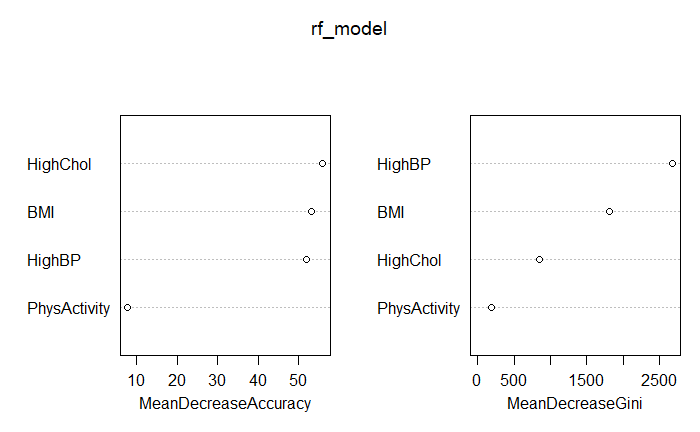

```r
# Step 6: Feature importance
importance_values <- importance(rf_model)
varImpPlot(rf_model)
```

```r
# Step 7: Optional - Save the model for future use
saveRDS(rf_model, "random_forest_model.rds")

# Step 8: Load the saved model (if needed later)
# rf_model <- readRDS("random_forest_model.rds")
```

#1. Random Forest Model Summary

Type of Random Forest: Classification model. Number of Trees: 500 decision trees were built. Variables Tried at Each Split: 3 predictors were randomly sampled at each split. Out-of-Bag (OOB) Error Rate: 13.79%. This indicates the model’s average classification error rate using the OOB samples.

##2. Confusion Matrix (OOB Data) Class Error: Class 0 has an error rate of 0.59% (high accuracy for classifying negatives). Class 1 has an error rate of 95.33% (low accuracy for classifying positives). The model struggles to classify the minority class (1), leading to high class error.

##3. Confusion Matrix and Statistics (Test Data) Accuracy: 86.21%, meaning the model correctly classifies ~86% of observations overall. Kappa: 0.063, indicating weak agreement between predicted and actual classes beyond chance. Sensitivity (Recall for 0): 99.46%, meaning the model detects almost all negative cases (0). Specificity (Recall for 1): 4.40%, meaning the model detects very few positive cases (1). Positive Predictive Value (PPV) for 0: 86.54%, meaning most predictions of 0 are correct. Negative Predictive Value (NPV) for 1: 56.81%, indicating relatively poor predictive ability for 1. Balanced Accuracy: The balanced accuracy is 51.93%, close to random guessing (50%). This is due to imbalanced class distribution.

# Why Resampling is Necessary

1. Class Imbalance Issue In the dataset, class 0 is significantly more frequent (majority class) than class 1 (minority class). The model prioritizes the majority class, leading to: High sensitivity and low specificity. Poor detection of the minority class (1), as shown by the confusion matrix and class error.
2. Impact of Imbalanced Data Accuracy alone is misleading because the model achieves high overall accuracy by focusing on the majority class (0). Metrics like Kappa, specificity, and balanced accuracy reveal the poor performance on minority class detection.
3. Need for Resampling Techniques

To address the imbalance and improve the model’s performance for both classes:

Oversampling: Increase the frequency of the minority class (1) by creating synthetic samples (e.g., SMOTE). Undersampling: Reduce the majority class size to match the minority class. Hybrid Techniques: Combine oversampling and undersampling for better balance. Class Weights: Penalize misclassifications of the minority class more heavily to make the model focus on it.

## Expected Benefits

Improved specificity (better detection of class 1). Balanced accuracy closer to 100%, indicating improved performance across both classes. More robust predictions for real-world scenarios with imbalanced data

```r
writeLines('PATH="${RTOOLS44_HOME}\\usr\\bin;${PATH}"', con = "~/.Renviron")
```

# Resampling

ROSE (Random Over-Sampling Examples) is an R package designed to handle class imbalance in datasets. It generates synthetic data by creating new samples for the minority class and/or reducing the samples of the majority class. The goal is to create a more balanced dataset for training machine learning models.

```r
 # Install and load the ROSE package
if (!require("ROSE")) install.packages("ROSE", dependencies = TRUE)
library(ROSE)

# Apply ROSE to balance the training data
set.seed(123)  # For reproducibility
balanced_train_data <- ROSE(
  Diabetes_binary ~ .,
  data = train_data,
  seed = 123
)$data

# Check the class distribution after balancing
cat("Class distribution in the balanced training data:\n")
```

```
Class distribution in the balanced training data:
```

```r
print(table(balanced_train_data$Diabetes_binary))
```

```
    0     1
88941 88636
```

```r
# Train Random Forest on the ROSE-balanced dataset
rf_model <- randomForest(Diabetes_binary ~ BMI + HighBP + HighChol + PhysActivity,
                         data = balanced_train_data,
                         ntree = 500,
                         mtry = 3,
                         importance = TRUE)

# Print model summary
print(rf_model)
```

```
Call:
 randomForest(formula = Diabetes_binary ~ BMI + HighBP + HighChol +      PhysActivity, data = balanced_train_data, ntree = 500, mtry = 3,      importance = TRUE)
               Type of random forest: classification
                     Number of trees: 500
No. of variables tried at each split: 3

        OOB estimate of  error rate: 32.01%
Confusion matrix:
      0     1 class.error
0 58958 29983   0.3371111
1 26868 61768   0.3031274
```

```r
# Predict on the test dataset
predictions <- predict(rf_model, test_data)

# Confusion matrix
conf_matrix <- confusionMatrix(predictions, test_data$Diabetes_binary)

# Print confusion matrix and metrics
print(conf_matrix)
```

```
Confusion Matrix and Statistics

          Reference
Prediction     0     1
         0 45302  3295
         1 20198  7308

               Accuracy : 0.6913
                 95% CI : (0.688, 0.6946)
    No Information Rate : 0.8607
    P-Value [Acc > NIR] : 1

                  Kappa : 0.2283

 Mcnemar's Test P-Value : <2e-16

            Sensitivity : 0.6916
            Specificity : 0.6892
         Pos Pred Value : 0.9322
         Neg Pred Value : 0.2657
             Prevalence : 0.8607
         Detection Rate : 0.5953
   Detection Prevalence : 0.6386
      Balanced Accuracy : 0.6904

       'Positive' Class : 0
```

# Random forest with Resampled dataset

Out-Of-Bag (OOB) Error Rate: 32.01%

This is the error rate calculated on the training dataset using out-of-bag samples (data not used to build a specific tree). It indicates the model’s ability to generalize. Observation: The OOB error is relatively high, suggesting room for improvement. Confusion Matrix (Training Set):

Class 0: Correctly Predicted: 58,958 Incorrectly Predicted: 29,983 (misclassified as Class 1) Class Error: 33.71% Class 1: Correctly Predicted: 61,768 Incorrectly Predicted: 26,868 (misclassified as Class 0) Class Error: 30.31% Evaluation Metrics on Test Data Accuracy: 69.13%

Indicates how well the model detects instances of Class 1 (true negatives). Kappa Statistic: 0.2283

Measures the agreement between predicted and actual values beyond chance. Low value suggests moderate improvement but still room for optimization. Balanced Accuracy: 69.04%

Average of sensitivity and specificity, providing a better measure for imbalanced datasets. Improvement: Earlier results showed significantly lower balanced accuracy due to the imbalance. McNemar’s Test P-Value: <2e-16

Indicates that the difference in prediction errors for the two classes is statistically significant. Improvements Compared to the Previous Model Class Balancing: The use of ROSE resulted in a more balanced dataset, improving the model’s ability to generalize across both classes.